# Homework Assignment 3

Author

Krish Patel

Published

March 9, 2024

- [LINK to GITHUB](https://github.com/cmsc-vcu/cmsc475-sp2024-hw3-kriishpatell)
- [LINK to FIGMA SHARE](https://www.figma.com/file/ZxkZHAHIcAlkK1VoB296Nc/HW2?type=design&node-id=16%3A142&mode=design&t=rTie5W5A5U59adGh-1)

## Board 1 - Contact Information

[interactive chart not shown]

This is my calling card with my contact information, my major, and graduation date. I utilized green because it is my favorite color, and used serif style font give it that old school flair.

## Board 2 - Connection

My first theme is *connection*. Below is my storyboard.

[interactive chart not shown]

I selected *connection* because I have been through a lot of life changing experiences and I learned that it is better to love than hate. One of the main experiences that I’ve had was watching Interstellar, which I think transitions nicely into my next card.

I animated a spinning earth using emojis, which switch on a time interval

## Board 3 - Curiosity

This theme is *curiosity*.

[interactive chart not shown]

I selected *curiosity* because I have always been curious about a lot of things, but astronomy has always highly piqued my interest. I often found myself researching astrophysics just for fun, not entirely grasping the concepts but just enjoying the facts.

I animated this with a slight shake at the beginning and the rocketship flying across the panel

## Board 4 - Passion

This theme is *passion*.

[interactive chart not shown]

I selected *passion* because I love volleyball. It introduced me to so many new people and new things and just a very welcoming community. I also very much enjoy the sport and hope to get better every day.

I changed my initial idea for animation of a hitter spiking the ball into just a ball that bounces along the panel, as I found that it was a lot easier based on my current skillset.

## Board 5 - Closing panel

[interactive chart not shown]

Just want to thank the viewer for taking the time to learn more about me. The previous panels were some of the words that I think truly define who I am.

I animated the page with it bouncing in from the top on repeat

# Reflection

I enjoyed the animation, there was a lot of trial and error, but I was able to figure it out eventually. I think that it would have been a lot better I worked in a more timely manner.

# Previous panels

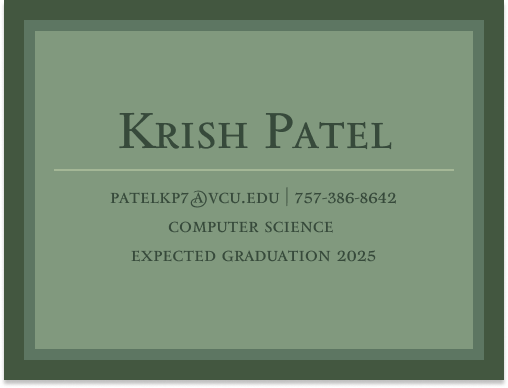

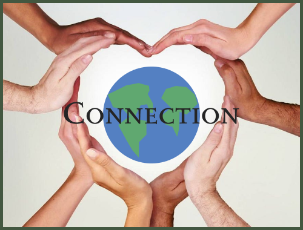

[figure not shown]

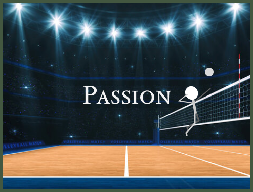

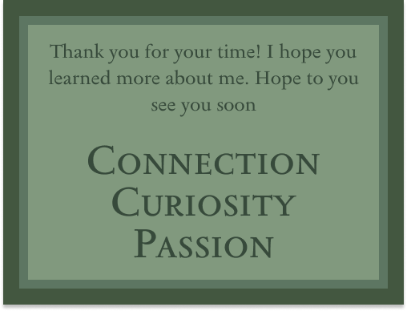